# Notebook

## Table of Content

- Problem Statement
  - Conditions of the noise
  - Notes
- Data Exploration
  - Base Model Proposal
  - Advance Model Proposal
- Modeling Approaches
  - MLE
    - 1 load data
    - 2 formulate a model
    - 3 the loss functions
    - 4-1 optimization by MLE
    - 4-2 optimization by square-loss loss function
    - 5 assessment
  - MAP
    - Solve the base model
    - Solve the advance model
- Modularize the procedure
  - calculate for each data set
- Result Summary

## Problem Statement

> Gaussian linear models are often insufficient in practical applications, where noise can be heavy-tailed. In this problem, we consider a linear model of the form $y_i = a \cdot x_i + b + e_i$. The $(e_i)$ are independent noise from a distribution that depends on $x$ as well as on global parameters; however, the noise distribution has conditional mean zero given $x$. The goal is to derive a good estimator for the parameters $a$ and $b$ based on a sample of observed $(x, y)$ pairs.

### Conditions of the noise

1. Independent noise: $P(e_i,e_j) = P(e_i)P(e_j)$
2. Depends on $x$ as well as on global parameters: $P(e_i) = f(x)$
3. Conditional mean zero given x: $E(e|X) = 0$

### Notes

[Heavy-tailed noise distribution](https://en.wikipedia.org/wiki/Heavy-tailed_distribution)

- fat-tailed
- long-tailed
- subexponential

## Data Exploration

```python
%pylab inline
```

```python
import pandas as pd
import seaborn as sns
```

Check data format

```python
!head -n 2 Problem1/data*csv
```

```
==> Problem1/data_1_1.csv <==
"x","y"
-2.344913368579,-0.553880573773964

==> Problem1/data_1_2.csv <==
"x","y"
7.65598999157864,25.7154901250775

==> Problem1/data_1_3.csv <==
"x","y"
-7.55903642645193,16.7701757838506

==> Problem1/data_1_4.csv <==
"x","y"
2.46604486601427,1.45975762203083

==> Problem1/data_1_5.csv <==
"x","y"
-4.49872666629194,0.408102071258836
```

```python
dset1 = pd.read_csv("Problem1/data_1_1.csv")
```

```python
dset1.describe()
```

|  | x | y |
| --- | --- | --- |
| count | 100.000000 | 100.000000 |
| mean | 0.178471 | -0.112328 |
| std | 2.675848 | 5.820218 |
| min | -4.866097 | -27.008035 |
| 25% | -1.769180 | -2.698194 |
| 50% | -0.121893 | -0.179928 |
| 75% | 2.671934 | 2.565632 |
| max | 4.919061 | 18.387174 |

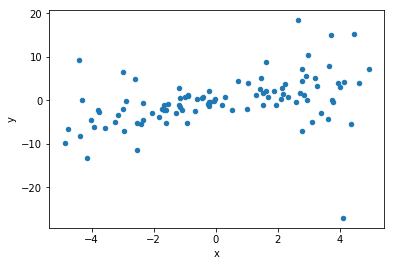

```python
dset1.plot(x='x', y='y',kind="scatter")
```

The problem has suggested to consider a linear model with some noise distribution. To start with, I will apply the "standard" least-squares fitting without noise consideration.

```
The best-fit value: a = 0.880809, b = -0.269527
```

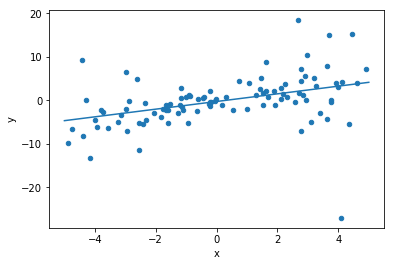

```python
p = polyfit(dset1.x, dset1.y, 1)
p_eval = poly1d(p)

dset1.plot(x='x', y='y',kind="scatter")
plot([-5, 5], p_eval([-5,5]))

print("The best-fit value: a = {:.6f}, b = {:.6f}".format(p[0],p[1]))
```

Now let's exam the residual of y based on the plain linear model.

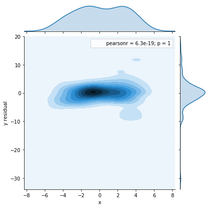

```python
sns.jointplot(dset1.x, pd.Series(dset1.y - p_eval(dset1.x), name="y residual"), kind="kde")
```

Check about other data set

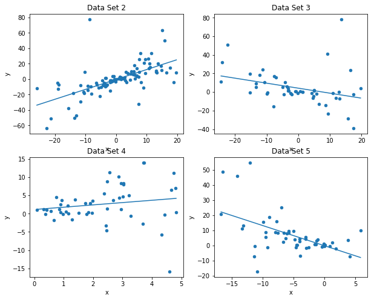

```python
fig = figure(figsize=(10,8))
for data_set in range(2,6):
    ax = fig.add_subplot(2,2,data_set-1)
    dset = pd.read_csv("Problem1/data_1_{}.csv".format(data_set))
    x, y = dset.x, dset.y
    pd.concat([x,y], axis=1).plot(x='x', y='y',kind="scatter", ax=ax)
    ax.plot([x.min(), x.max()], poly1d(polyfit(x, y, 1))([x.min(), x.max()]))
    title("Data Set {}".format(data_set))
```

All data sets have similar trend of noise. I will continue exploring with data set 1.

### Base Model Proposal

The noise has a trend of Gaussian-like distribution at any given $x$, with conditional mean at zero (as told in condition 3). At the same time, the distribution tends to be flatter when $x$ is farther away from zero. It suggests an amplifying noise when away from equilibrium position at $x = 0$

The simplest assumption is that $e_i(x) = x_i \cdot N(0,1)$, a linear amplifying noise. This model can be written as:

$$ y_i = a \cdot x_i + b + x_i \cdot N(0, 1)$$

```
Text(0.5,1,'abs(y_res) vs abs(x): flip along both axis')
```

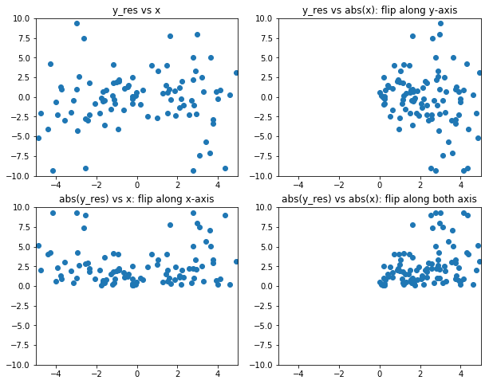

```python
fig = figure(figsize=(10,8))
ax1 = fig.add_subplot(221)
ax1 = scatter(dset1.x, pd.Series((dset1.y - p_eval(dset1.x)), name="y residual"))
xlim([-5,5])
ylim([-10,10])
title("y_res vs x")

ax2 = fig.add_subplot(223)
ax2 = scatter(dset1.x, pd.Series(abs(dset1.y - p_eval(dset1.x)), name="y residual"))
xlim([-5,5])
ylim([-10,10])
title("abs(y_res) vs x: flip along x-axis")

ax3 = fig.add_subplot(222)
ax3 = scatter(abs(dset1.x), pd.Series((dset1.y - p_eval(dset1.x)), name="y residual"))
xlim([-5,5])
ylim([-10,10])
title("y_res vs abs(x): flip along y-axis")

ax3 = fig.add_subplot(224)
ax3 = scatter(abs(dset1.x), pd.Series(abs(dset1.y - p_eval(dset1.x)), name="y residual"))
xlim([-5,5])
ylim([-10,10])
title("abs(y_res) vs abs(x): flip along both axis")
```

### Advance Model Proposal

In general, a linear relationship between data should only be assumed if there is a very strong theoretical motivation for such a relationship. Otherwise, the relationship could be just about anything, and inference based on an assumption of linearity may lead to dramatically incorrect conclusions. It also applies to any assumptions to noise. In this case, the problem statement has indicated to consider a linear model of $(x,y)$. But we have no prior knowledge about the noise except for the three conditions.

More complicated noise model with conditional mean zero can be built based on the property of [location-scale family](https://en.wikipedia.org/wiki/Location%E2%80%93scale_family), using Normal, Cauthy, Logistic, Laplace, student-t, etc. Here I will stay with Normal (Gaussian) distribution as it's the most common distribution, but the noise variation against $x_i$ can be more complicated.

$$ y_i = a \cdot x_i + b + f(x_i) * N(0, 1)$$

With no special reason, I will define $f(x_i) = c * x_i^2 + d * x_i + e$ for comparison.

## Modeling Approaches

There are two approaches to solve this problem:

1. Frequentist approach: Maximum Likelihood Estimation
2. Bayesian approach: Maximum A Posterior

There is no difference in technical aspect. Basically, it converts the regression into an optimization problem. The best fit parameters will be derived by maximizing the likelihood function or minimizing the loss function. I will skip the theoretical argue until justifying the assessment of the estimation quality.

### Approach 1: Maximum Likelihood Estimation

### 1. load the data

```python
def load_data(data_set=1):
    """
    load data from Problem1/data_1_*.csv file
    ------
    input:
        data_set: int, default 1
    output:
        (x, y): pandas data series of same length
    """
    try:
        data = pd.read_csv("Problem1/data_1_{}.csv".format(data_set))
    except:
        print("Cannot load data, check Problem1/data_1_{}.csv".format(data_set))
    return (data.x, data.y)
```

```python
x, y = load_data(1)
```

### 2. Formulate a model

Base model: $ y_i = a \cdot x_i + b + x_i \cdot N(0, 1)$, with parameter $a, b$

Advance model: $ y_i = a \cdot x_i + b + (c \cdot x_i^2 + d \cdot x_i + e) \cdot N(0, 1)$, with parameter $a, b, c, d, e$

### 3. The loss function

Maximizing the loglikelihood function in MLE is equivalent to minimizing the "chi-square".

For the base model,

- the likelihood function: $$\mathcal{L}(a,b; y,X) = (2\pi)^{-\frac{N}{2}} \exp{\left(-\frac{1}{2} \sum_{i=1}^{N} \left( \frac{y_i - a\cdot x_i -b}{x_i} \right)^2 \right)}$$
- the loglikelihood function: $$\log\mathcal{L}(a,b; y,X) = - \frac{N}{2} \log(2\pi) -\frac{1}{2} \sum_{i=1}^{N} \left( \frac{y_i - a\cdot x_i -b}{x_i} \right)^2$$
- a chi-square loss function: $$\chi^2 = \sum_{i=1}^{N} \left( \frac{y_i - a\cdot x_i -b}{x_i} \right)^2 \propto (-2\log\mathcal{L}) $$

If $x_i$ is treated as a factor of the variance in the covariance matrix $C$, the loss function can be write into:

$$\chi^2 = \sum_{i=1}^{N} \frac{ [y_i - a\cdot x_i -b]^2 } {\sigma_i^2} = [Y - AX]^T C^{-1} [Y - AX] $$ where

### 4. Solve the optimization problem

The optimal of loss function will be achieved at $$\frac{\partial \chi^2}{\partial \theta} = 0$$ where, $\theta \in \{a, b\}$.

Or straightforward from the linear algebra form, $Y = AX$ is the solution to minimize the loss function. With no need of complicated derivation, the equation for the best-fit parameters will be

$$[[a],[b]] = X = [A^T C^{-1} A]^{-1} [A^T C^{-1} Y]$$

```
The best-fit value: a = 0.924112, b = 0.038162
```

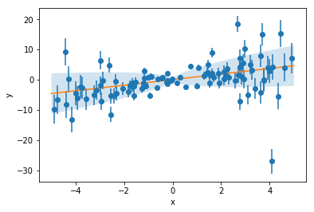

```python
# vectorize
Y = y.values.reshape(-1, 1)
A = vstack((ones_like(x), x)).T
C = diag(abs(x))

# minimize the chi-square loss function for a, b
X = linalg.inv(A.transpose()@linalg.inv(C)@A) @ (A.transpose()@linalg.inv(C)@Y)
b = X[0][0]
a = X[1][0]

# visualize the data and standard linear model
st_fit = poly1d([a,b])
pd.concat([x,y], axis=1).plot(x='x', y='y',kind="scatter")
errorbar(x, y, x, fmt='o')
plot([-5, 5], st_fit([-5, 5]))

# 3 sigma area
xs = linspace(-5,5,100)
fill_between(xs, a*xs + b + 3*sqrt(abs(xs)), a*xs + b - 3*sqrt(abs(xs)), alpha=0.2)

print("The best-fit value: a = {:.6f}, b = {:.6f}".format(a, b))
```

### Another method

Sometimes, it is not intuitive to write down the analytic solution. The standard numerical method is to define the square-loss as the loss function:

**Square-loss loss function** $$ \text{sloss} = \frac{1}{2} \sum_{i=1}^N \frac{[y_i - a \cdot x_i - b]^2}{\sigma_i^2} $$

which is the same as the $\chi^2$ loss function we derived from the likelihood function.

```python
def square_loss(theta, x=x, y=y, var=abs(x)):
    dy = y - theta[0]*x - theta[1]
    return sum(0.5 * dy**2/var)
```

**Numerical method for optimization**

The `optimize` function from `scipy` can be used to find the minimum value for the square-loss loss function.

```python
from scipy import optimize
```

```python
a, b = optimize.fmin(square_loss, [0, 0], disp=False)
print("The best-fit value: a = {:.6f}, b = {:.6f}".format(a, b))
```

```
The best-fit value: a = 0.924087, b = 0.038190
```

### 5. Assessment

A very simple and direct metric is to use the total square loss.

```python
# the benchmark from standard linear fit, without noise consideration
print("The square-loss from standard linear fit: {:.4f}".format(square_loss(polyfit(x, y, 1), x, y, abs(x))))
```

```
The square-loss from standard linear fit: 484.6278
```

```python
# the square loss of the base model
print("The square-loss from the base model: {:.4f}".format(square_loss([a, b], x, y, abs(x))))
```

```
The square-loss from the base model: 477.7449
```

**The base model with linear amplifying noise already performs better than a brute-force linear fit.**

Of course, to properly conduct assessment for model selection, we should adopt hypothesis test. The square-loss may not be the best metric, when outliers present.

### Approach 2: Maximum A Posteriori

It is not my invention to prefer Bayesianism rather than frequentism. A simplified discussion about the difference and suggestion is published at [Jake's paper](https://arxiv.org/abs/1411.5018).

For the Bayesian approach, a prior distribution $g$ over parameters $a, b$ is first assumed. Therefore, the unobserved parameters can be treated as random variables. The posterior distribution of $a,b$ can be calculated by:

$$ f(a,b|X) = \frac{f(X|a,b)g(a,b)}{\int f(X|x)g(x)d x} $$

where

$f(X|a,b)$ is the likelihood in frequentist approach. $g(a,b)$ is the model prior, represents one's belief about this quantity before some evidence is taken into account. $\int f(X|x)g(x)dx$ is the probability of evidence, which is the total data probability. The general form of Bayes' theorem is: $$P(A|B) = \frac{P(B|A)P(A)}{P(B)}$$

Unlike assuming an existing true parameter in MLE and comparing the fitness of the data, Bayesian approach will give a posterior distribution of the estimated parameter based on data. It doesn't need additional assumption to assess the estimation quality of the parameter.

The posterior can be numerically solved by Monte Carlo sampling in `PYMC3`.

```python
import pymc3 as pm
```

### Solve the base model

```python
nsample = 1000

with pm.Model() as model:
    # priors
    sigma = abs(x)  # base model
    b = pm.Uniform('b', lower=0, upper=5)  # non-informative prior
    a = pm.Uniform('a', lower=0, upper=5)  # non-informative prior

    # likelihood
    likelihood = pm.Normal('y', mu = a*x + b, \
                        sd=sigma, observed=y)
    # Inference
    start = pm.find_MAP() # Find starting value by optimization
    step = pm.NUTS(scaling=start) # Instantiate MCMC sampling algorithm
    trace = pm.sample(nsample, step, start=start, progressbar=True, njobs=4) # run with 4 cores
```

```
Multiprocess sampling (4 chains in 4 jobs)
NUTS: [a_interval__, b_interval__]
```

```
array([[<matplotlib.axes._subplots.AxesSubplot object at 0x117cd16a0>,
        <matplotlib.axes._subplots.AxesSubplot object at 0x117d18f28>]], dtype=object)
```

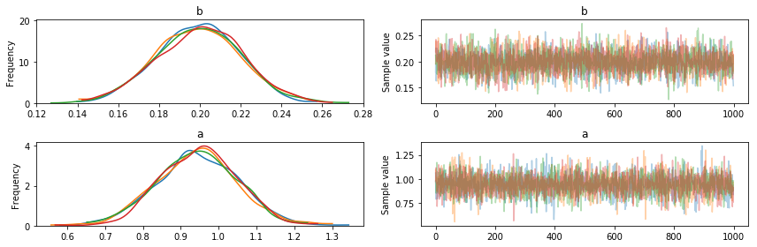

```python
pm.traceplot(trace)
```

`traceplot` provides

- marginal posterior distribution for each parameter (left)
- the time series of the parameter values from the chain (right)

```python
pm.summary(trace)
```

|  | mean | sd | mc_error | hpd_2.5 | hpd_97.5 | n_eff | Rhat |
| --- | --- | --- | --- | --- | --- | --- | --- |
| b | 0.199333 | 0.020625 | 0.000359 | 0.158306 | 0.239466 | 3692.0 | 1.000289 |
| a | 0.943977 | 0.104342 | 0.001909 | 0.747241 | 1.147883 | 3291.0 | 0.999842 |

Compare with MLE models

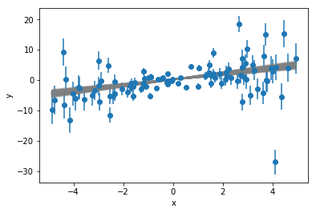

```python
a_avg, a_sd = pm.summary(trace[-100:]).loc['a',['mean','sd']]
b_avg, b_sd = pm.summary(trace[-100:]).loc['b',['mean','sd']]

### Plot the predictive posterior samples
pd.concat([x, y], axis=1).plot(x='x', y='y',kind="scatter")
errorbar(x, y, x, fmt='o')
for a_, b_ in zip(trace['a'][-500:], trace['b'][-500:]):
    plt.plot(x, a_*x +b_, c='gray', alpha=0.1)
```

```python
print("The best-fit value: a = {:.6f} with sd = {:.4f}, b = {:.6f} with sd = {:.4f}".format(
    a_avg, a_sd, b_avg, b_sd))
print("The square-loss from the base model: {:.4f}".format(square_loss([a_avg, b_avg], x, y, abs(x))))
```

```
The best-fit value: a = 0.939489 with sd = 0.1066, b = 0.198840 with sd = 0.0184
The square-loss from the base model: 479.5947
```

### Solve the advance model

$$ y_i = a \cdot x_i + b + (c \cdot x_i^2 + d \cdot x_i + e) \cdot N(0, 1)$$ with parameter $a, b, c, d, e$

```python
nsample = 2000

with pm.Model() as model:
    # priors
    c = pm.Normal('c', sd=10)
    d = pm.Normal('d', sd=10)
    e = pm.Uniform('e', lower=0, upper=5)
    sigma = abs(c * x**2 + d * x + e)
    b = pm.Uniform('b', lower=-2, upper=1)  # non-informative prior
    a = pm.Uniform('a', lower=0, upper=5)  # non-informative prior

    # likelihood
    likelihood = pm.Normal('y', mu = a*x + b, \
                        sd=sigma, observed=y)
    # Inference
    start = pm.find_MAP() # Find starting value by optimization
    step = pm.NUTS(scaling=start) # Instantiate MCMC sampling algorithm
    trace = pm.sample(nsample, step, start=start, progressbar=True, njobs=4) # run with 4 cores
```

```
Multiprocess sampling (4 chains in 4 jobs)
NUTS: [a_interval__, b_interval__, e_interval__, d, c]
```

```
array([[<matplotlib.axes._subplots.AxesSubplot object at 0x115e645f8>,
        <matplotlib.axes._subplots.AxesSubplot object at 0x115d85048>]], dtype=object)
```

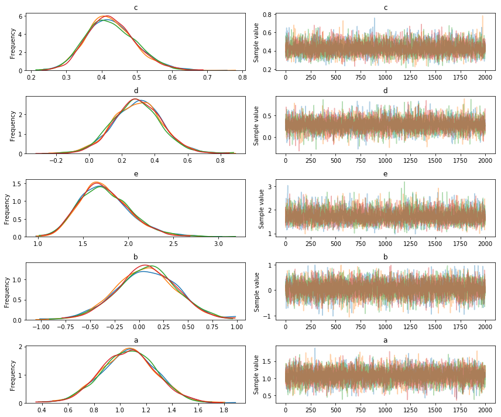

```python
pm.traceplot(trace)
```

```python
pm.summary(trace)
```

|  | mean | sd | mc_error | hpd_2.5 | hpd_97.5 | n_eff | Rhat |
| --- | --- | --- | --- | --- | --- | --- | --- |
| c | 0.427024 | 0.069296 | 0.000936 | 0.303095 | 0.572728 | 5660.0 | 1.000058 |
| d | 0.293089 | 0.149467 | 0.001801 | -0.012319 | 0.578886 | 7323.0 | 1.000431 |
| e | 1.736824 | 0.280242 | 0.003820 | 1.250578 | 2.319825 | 5620.0 | 0.999969 |
| b | 0.077992 | 0.306658 | 0.003849 | -0.539430 | 0.668089 | 6163.0 | 1.000044 |
| a | 1.062852 | 0.208842 | 0.002456 | 0.652912 | 1.463064 | 6999.0 | 0.999815 |

```python
a_avg, a_sd = pm.summary(trace[-100:]).loc['a',['mean','sd']]
b_avg, b_sd = pm.summary(trace[-100:]).loc['b',['mean','sd']]
c = pm.summary(trace[-100:]).loc['c',['mean']].values
d = pm.summary(trace[-100:]).loc['d',['mean']].values
e = pm.summary(trace[-100:]).loc['e',['mean']].values
```

Compare with MAP base model

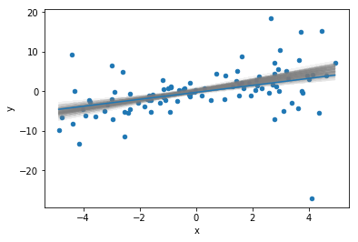

```python
### Plot the predictive posterior samples
pd.concat([x,y], axis=1).plot(x='x', y='y',kind="scatter")

for a_, b_ in zip(trace['a'][-100:], trace['b'][-100:]):
    plot(x, a_*x +b_, c='gray', alpha=0.1)

plot([x.min(), x.max()], poly1d(polyfit(x, y, 1))([x.min(), x.max()]))
```

```python
print("The best-fit value: a = {:.6f} with sd = {:.4f}, b = {:.6f} with sd = {:.4f}".format(
    a_avg, a_sd, b_avg, b_sd))
```

```
The best-fit value: a = 1.067246 with sd = 0.1977, b = 0.054402 with sd = 0.2925
```

```python
print("The square-loss from the advanced model: {:.4f}".format(square_loss([a_avg, b_avg], x, y, abs(c * x**2 + d * x +e))))
```

```
The square-loss from the advanced model: 218.3484
```

### Modularize the procedure

```python
def MLE(x, y, plot_flag=False):
    """
    Maximum Likelihood Estimator for Linear Model
    ----
    input
        x: pandas data series
        y: pandas data series
        plot_flag: boolean
    """

    # vectorize
    Y = y.values.reshape(-1, 1)
    A = vstack((ones_like(x), x)).T
    C = diag(abs(x))

    # minimize the chi-square loss function for a, b
    X = linalg.inv(A.transpose()@linalg.inv(C)@A) @ (A.transpose()@linalg.inv(C)@Y)
    b = X[0][0]
    a = X[1][0]

    # visualize the data and standard linear model
    if plot_flag:
        st_fit = poly1d([a,b])
        pd.concat([x,y], axis=1).plot(x='x', y='y',kind="scatter")
        errorbar(x, y, x, fmt='o')
        plot([x.min(), x.max()], st_fit([x.min(), x.max()]))

        # 3 sigma area
        xs = linspace(x.min(),x.max(),100)
        fill_between(xs, a*xs + b + 3*sqrt(abs(xs)), a*xs + b - 3*sqrt(abs(xs)), alpha=0.2)
#         savefig('MLE.jpg')

    # the benchmark from direct linear fit, without noise consideration
    print("Benchmark")
    print("\tThe best-fit value: a = {:.6f}, b = {:.6f}".format(polyfit(x, y, 1)[0], polyfit(x, y, 1)[1]))
    print("\tThe square-loss from standard linear fit: {:.4f}".format(square_loss(polyfit(x, y, 1), x, y, abs(x))))

    print("MLE approach")
    print("\tThe best-fit value: a = {:.6f}, b = {:.6f}".format(a, b))
    # the square loss of the base model
    print("\tThe square-loss from the base model: {:.4f}".format(square_loss([a, b], x, y, abs(x))))
    return (a,b)

def MAP_base(a_guess, b_guess, x, y, nsample=1000, plot_flag=False):
    """
    Maximum A Posteriori Estimator for Linear Model with Linear Noise
    ----
    input
        a_guess: float, initial guess of the slope
        b_guess: float, initial guess of the y-intercept
        x: pandas data series
        y: pandas data series
        nsample: int, number of sample in MCMC chain
        plot_flag: boolean
    """
    with pm.Model() as model:
        # priors
        sigma = abs(x)  # base model
        b = pm.Uniform('b', lower=b_guess-5, upper=b_guess+5)  # non-informative prior
        a = pm.Uniform('a', lower=a_guess-5, upper=a_guess+5)  # non-informative prior

        # likelihood
        likelihood = pm.Normal('y', mu = a*x + b, \
                            sd=sigma, observed=y)
        # Inference
        start = pm.find_MAP() # Find starting value by optimization
        step = pm.NUTS(scaling=start) # Instantiate MCMC sampling algorithm
        trace = pm.sample(nsample, step, start=start, progressbar=True, njobs=4) # run with 4 cores

    pm.traceplot(trace)
    a_avg, a_sd = pm.summary(trace[-int(0.1*nsample):]).loc['a',['mean','sd']]
    b_avg, b_sd = pm.summary(trace[-int(0.1*nsample):]).loc['b',['mean','sd']]

    if plot_flag:
        ### Plot the predictive posterior samples
        pd.concat([x,y], axis=1).plot(x='x', y='y',kind="scatter")
        errorbar(x, y, x, fmt='o')

        for a_, b_ in zip(trace['a'][-int(0.1*nsample):], trace['b'][-int(0.1*nsample):]):
            plot(x, a_*x +b_, c='gray', alpha=0.1)

        plot([x.min(), x.max()], poly1d(polyfit(x, y, 1))([x.min(), x.max()]))
#         savefig('MAP_base.jpg')

    print("MAP approach for base model")
    print("\tThe best-fit value: a = {:.6f} with sd = {:.4f}, b = {:.6f} with sd = {:.4f}".format(
        a_avg, a_sd, b_avg, b_sd))
    print("\tThe square-loss from the base model: {:.4f}".format(square_loss([a_avg, b_avg], x, y, abs(x))))
    return (a_avg, b_avg)

def MAP_ad(a_guess, b_guess, x, y, nsample=2500, plot_flag=False):
    """
    Maximum A Posteriori Estimator for Linear Model with Polynomial Noise
    ----
    input
        a_guess: float, initial guess of the slope
        b_guess: float, initial guess of the y-intercept
        x: pandas data series
        y: pandas data series
        nsample: int, number of sample in MCMC chain
        plot_flag: boolean
    """
    with pm.Model() as model:
        # priors
        c = pm.Normal('c', sd=1)
        d = pm.Normal('d', sd=10)
        e = pm.Uniform('e', lower=0, upper=10)
        sigma = abs(c * x**2 + d * x + e)

        b = pm.Uniform('b', lower=b_guess-5, upper=b_guess+5)  # non-informative prior
        a = pm.Uniform('a', lower=a_guess-5, upper=a_guess+5)  # non-informative prior

        # likelihood
        likelihood = pm.Normal('y', mu = a*x + b, \
                            sd=sigma, observed=y)
        # Inference
        start = pm.find_MAP() # Find starting value by optimization
        step = pm.NUTS(scaling=start) # Instantiate MCMC sampling algorithm
        trace = pm.sample(nsample, step, start=start, progressbar=True, njobs=4) # run with 4 cores

    pm.traceplot(trace)
    a_avg, a_sd = pm.summary(trace[-int(0.1*nsample):]).loc['a',['mean','sd']]
    b_avg, b_sd = pm.summary(trace[-int(0.1*nsample):]).loc['b',['mean','sd']]
    c = pm.summary(trace[-int(0.1*nsample):]).loc['c',['mean']].values
    d = pm.summary(trace[-int(0.1*nsample):]).loc['d',['mean']].values
    e = pm.summary(trace[-int(0.1*nsample):]).loc['e',['mean']].values

    if plot_flag:
        ### Plot the predictive posterior samples
        pd.concat([x,y], axis=1).plot(x='x', y='y',kind="scatter")

        for a_, b_ in zip(trace['a'][-int(0.1*nsample):], trace['b'][-int(0.1*nsample):]):
            plot(x, a_*x +b_, c='gray', alpha=0.1)

        plot([x.min(), x.max()], poly1d(polyfit(x, y, 1))([x.min(), x.max()]))
#         savefig('MAP_ad.jpg')

    print("MAP approach for advanced model")
    print("\tThe best-fit value: a = {:.6f} with sd = {:.4f}, b = {:.6f} with sd = {:.4f}".format(
        a_avg, a_sd, b_avg, b_sd))
    print("\tThe square-loss from the advanced model: {:.4f}".format(square_loss([a_avg, b_avg], x, y, abs(c * x**2 + d * x +e))))
    return (a_avg, b_avg)
```

```python
result = []
```

### Data Set 1 (again)

```
Benchmark
	The best-fit value: a = 0.880809, b = -0.269527
	The square-loss from standard linear fit: 484.6278
MLE approach
	The best-fit value: a = 0.924112, b = 0.038162
	The square-loss from the base model: 477.7449
```

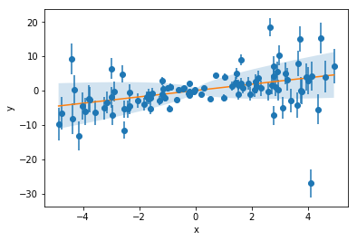

```python
data_set = 1
x, y = load_data(data_set)
a_, b_ = MLE(x=x, y=y, plot_flag=True)
```

```
Multiprocess sampling (4 chains in 4 jobs)
NUTS: [a_interval__, b_interval__]
```

```
MAP approach for base model
	The best-fit value: a = 0.941182 with sd = 0.1033, b = 0.198855 with sd = 0.0195
	The square-loss from the base model: 479.6003
```

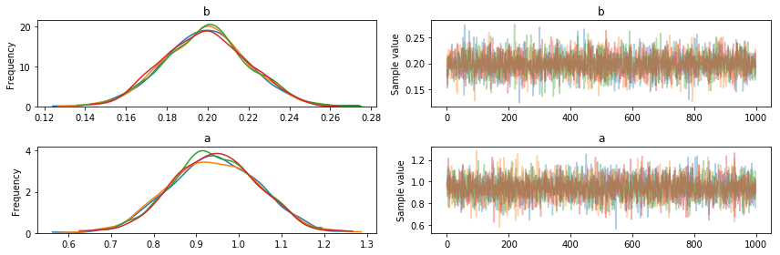

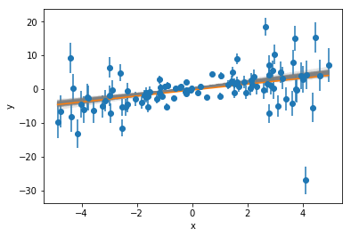

```python
a_, b_ = MAP_base(a_guess=a_, b_guess=b_, x=x, y=y, plot_flag=True)
```

```
Multiprocess sampling (4 chains in 4 jobs)
NUTS: [a_interval__, b_interval__, e_interval__, d, c]
There were 1 divergences after tuning. Increase `target_accept` or reparameterize.
```

```
MAP approach for advanced model
	The best-fit value: a = 1.059535 with sd = 0.2040, b = 0.077346 with sd = 0.3036
	The square-loss from the advanced model: 217.3923
```

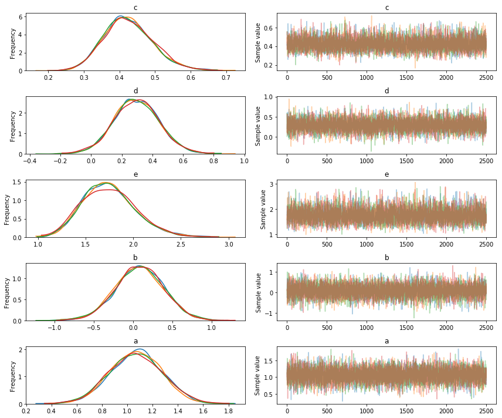

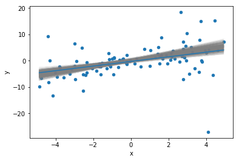

```python
a_, b_ = MAP_ad(a_guess=a_, b_guess=b_, x=x, y=y, plot_flag=True)
```

```python
result.append(["data_1_{}.csv".format(data_set), a_, b_])
result[data_set-1]
```

```
['data_1_1.csv', 1.0595345555052258, 0.07734621028176958]
```

### Data Set 2

```
Benchmark
	The best-fit value: a = 1.285603, b = -0.395853
	The square-loss from standard linear fit: 1275.1328
MLE approach
	The best-fit value: a = 1.272313, b = -0.806160
	The square-loss from the base model: 1269.6213
```

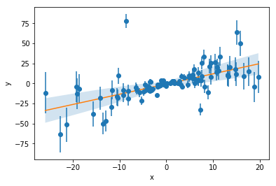

```python
data_set = 2
x, y = load_data(data_set)
a_, b_ = MLE(x=x, y=y, plot_flag=True)
```

```
Multiprocess sampling (4 chains in 4 jobs)
NUTS: [a_interval__, b_interval__]
```

```
MAP approach for base model
	The best-fit value: a = 1.620709 with sd = 0.1084, b = -0.832424 with sd = 0.0424
	The square-loss from the base model: 1317.0249
```

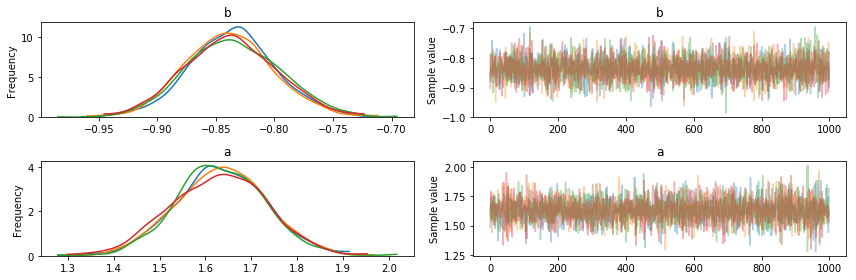

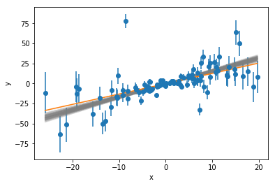

```python
a_, b_ = MAP_base(a_guess=a_, b_guess=b_, x=x, y=y, plot_flag=True)
```

```
Multiprocess sampling (4 chains in 4 jobs)
NUTS: [a_interval__, b_interval__, e_interval__, d, c]
```

```
MAP approach for advanced model
	The best-fit value: a = 1.215116 with sd = 0.1867, b = -0.704479 with sd = 0.6083
	The square-loss from the advanced model: 577.8528
```

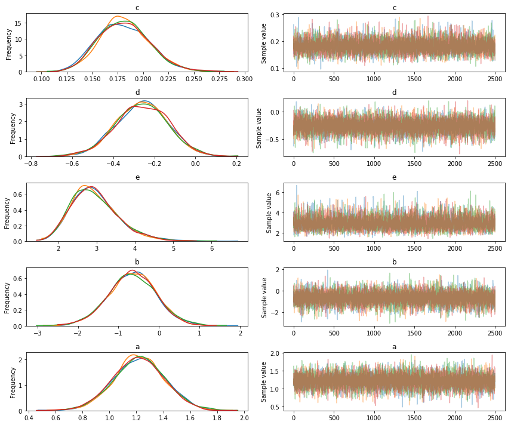

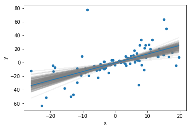

```python
a_, b_ = MAP_ad(a_guess=a_, b_guess=b_, x=x, y=y, plot_flag=True)
```

```python
result.append(["data_1_{}.csv".format(data_set), a_, b_])
result[data_set-1]
```

```
['data_1_2.csv', 1.2151158827281496, -0.7044785164742667]
```

### Data Set 3

```
Benchmark
	The best-fit value: a = -0.537850, b = 4.175155
	The square-loss from standard linear fit: 769.7736
MLE approach
	The best-fit value: a = -0.469547, b = 0.533146
	The square-loss from the base model: 642.4036
```

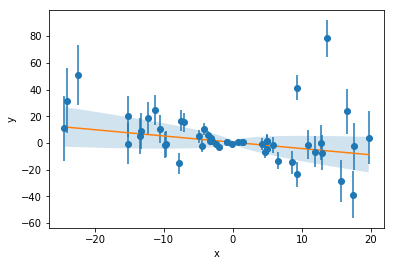

```python
data_set = 3
x, y = load_data(data_set)
a_, b_ = MLE(x=x, y=y, plot_flag=True)
```

```
Multiprocess sampling (4 chains in 4 jobs)
NUTS: [a_interval__, b_interval__]
```

```
MAP approach for base model
	The best-fit value: a = -0.407798 with sd = 0.1446, b = -0.911191 with sd = 0.1301
	The square-loss from the base model: 663.3336
```

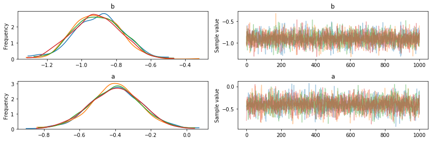

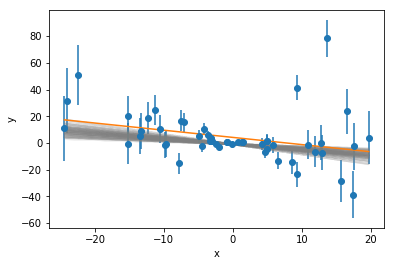

```python
a_, b_ = MAP_base(a_guess=a_, b_guess=b_, x=x, y=y, plot_flag=True)
```

```
Multiprocess sampling (4 chains in 4 jobs)
NUTS: [a_interval__, b_interval__, e_interval__, d, c]
There were 4 divergences after tuning. Increase `target_accept` or reparameterize.
There were 3 divergences after tuning. Increase `target_accept` or reparameterize.
There were 7 divergences after tuning. Increase `target_accept` or reparameterize.
There were 3 divergences after tuning. Increase `target_accept` or reparameterize.
```

```
MAP approach for advanced model
	The best-fit value: a = -0.440284 with sd = 0.2384, b = 0.258148 with sd = 0.6257
	The square-loss from the advanced model: 308.8886
```

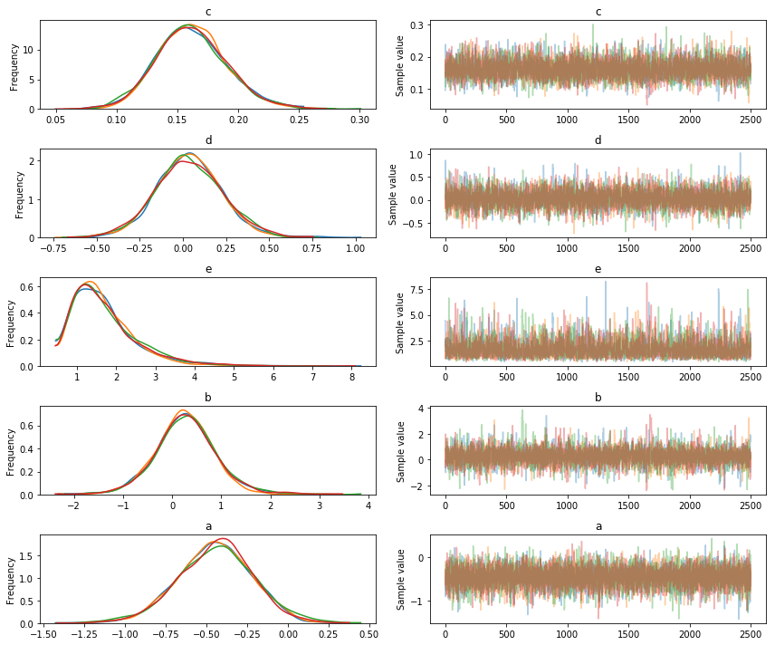

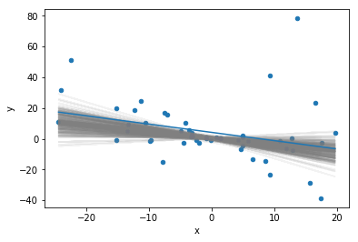

```python
a_, b_ = MAP_ad(a_guess=a_, b_guess=b_, x=x, y=y, plot_flag=True)
```

```python
result.append(["data_1_{}.csv".format(data_set), a_, b_])
result[data_set-1]
```

```
['data_1_3.csv', -0.44028431960494835, 0.25814827042720206]
```

### Data Set 4

```
Benchmark
	The best-fit value: a = 0.633376, b = 1.148131
	The square-loss from standard linear fit: 205.8768
MLE approach
	The best-fit value: a = 0.854638, b = 0.641194
	The square-loss from the base model: 202.8280
```

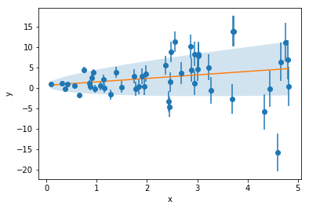

```python
data_set = 4
x, y = load_data(data_set)
a_, b_ = MLE(x=x, y=y, plot_flag=True)
```

```
Multiprocess sampling (4 chains in 4 jobs)
NUTS: [a_interval__, b_interval__]
```

```
MAP approach for base model
	The best-fit value: a = 0.683492 with sd = 0.1731, b = 0.840995 with sd = 0.0898
	The square-loss from the base model: 203.7052
```

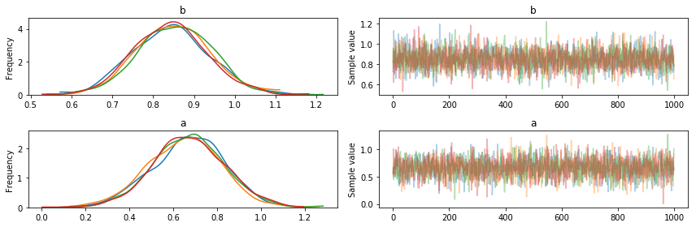

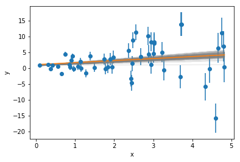

```python
a_, b_ = MAP_base(a_guess=a_, b_guess=b_, x=x, y=y, plot_flag=True)
```

```
Multiprocess sampling (4 chains in 4 jobs)
NUTS: [a_interval__, b_interval__, e_interval__, d, c]
The chain reached the maximum tree depth. Increase max_treedepth, increase target_accept or reparameterize.
The chain reached the maximum tree depth. Increase max_treedepth, increase target_accept or reparameterize.
The acceptance probability does not match the target. It is 0.888114900373, but should be close to 0.8. Try to increase the number of tuning steps.
The chain reached the maximum tree depth. Increase max_treedepth, increase target_accept or reparameterize.
The chain reached the maximum tree depth. Increase max_treedepth, increase target_accept or reparameterize.
The gelman-rubin statistic is larger than 1.2 for some parameters.
The estimated number of effective samples is smaller than 200 for some parameters.
```

```
MAP approach for advanced model
	The best-fit value: a = 0.501452 with sd = 0.2670, b = 0.937669 with sd = 0.2581
	The square-loss from the advanced model: 96.0215
```

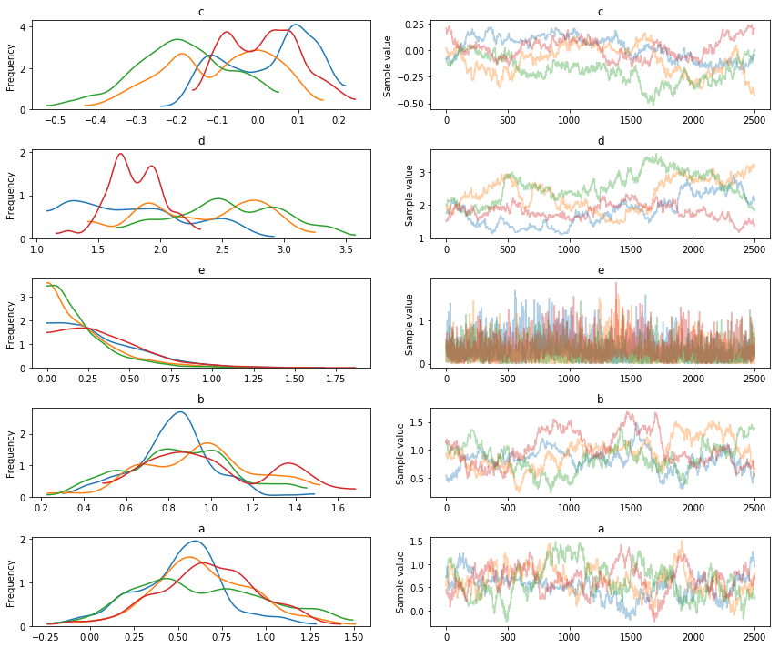

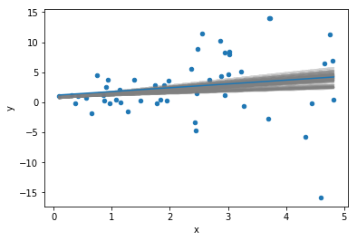

```python
a_, b_ = MAP_ad(a_guess=a_, b_guess=b_, x=x, y=y, plot_flag=True)
```

Not all chains have stabilized and converged, but I will stop here due to the time-consuming computation efficiency tunning.

```python
result.append(["data_1_{}.csv".format(data_set), a_, b_])
result[data_set-1]
```

```
['data_1_4.csv', 0.5014516571437767, 0.9376692741838497]
```